# Integrated Project 1

Author: Jinyu Du

Submission date: Dec.21, 2021

## Project description

We have a dataset from the online store Ice, which sells video games all over the world. User and expert reviews, genres, platforms (e.g. Xbox or PlayStation), and historical data on game sales are available from open sources. We want to identify patterns that determine whether a game succeeds or not. This will allow us to spot potential big winners and plan advertising campaigns.

The dataset was from 2016. Let’s imagine that it’s December 2016 and we were planning a campaign for 2017. The dataset contains the abbreviation ESRB. The Entertainment Software Rating Board evaluates a game's content and assigns an age rating such as Teen or Mature.

## Data description

- Name
- Platform
- Year_of_Release
- Genre
- NA_sales (North American sales in USD million)
- EU_sales (sales in Europe in USD million)
- JP_sales (sales in Japan in USD million)
- Other_sales (sales in other countries in USD million)
- Critic_Score (maximum of 100)
- User_Score (maximum of 10)
- Rating (ESRB)

Note: Data for 2016 may be incomplete.

## Purpose of the project

1. Load the dataset, data cleaning and wrangling
2. Fix and enrich data, and fill in missing values
3. Draw insights about sales across platforms, regions and genres
4. Perform statistical hypothesis tests to check whether the average user ratings of the Xbox One and PC platforms are the same
5. Perform statistical hypothesis tests to check whether the average user ratings for the Action and Sports genres are different
6. Provide business insights for the 2017 sales campaign

## Initialization

```python
# Loading all the libraries

import pandas as pd
import numpy as np
from matplotlib import pyplot as plt
import seaborn as sns
from scipy import stats as st
import math as mt
```

## Load data

```python
# Load the data file into a DataFrame

games = pd.read_csv('games.csv')
```

## Initial data exploration and data cleaning

```python
games.duplicated().sum()
```

```
0
```

There are no duplicated rows in the dataset.

```python
# Print the general/summary information about the DataFrame

games.info()
```

```
<class 'pandas.core.frame.DataFrame'>
RangeIndex: 16715 entries, 0 to 16714
Data columns (total 11 columns):
 #   Column           Non-Null Count  Dtype
---  ------           --------------  -----
 0   Name             16713 non-null  object
 1   Platform         16715 non-null  object
 2   Year_of_Release  16446 non-null  float64
 3   Genre            16713 non-null  object
 4   NA_sales         16715 non-null  float64
 5   EU_sales         16715 non-null  float64
 6   JP_sales         16715 non-null  float64
 7   Other_sales      16715 non-null  float64
 8   Critic_Score     8137 non-null   float64
 9   User_Score       10014 non-null  object
 10  Rating           9949 non-null   object
dtypes: float64(6), object(5)
memory usage: 1.4+ MB
```

The `games` dataframe has 16715 rows and 11 columns. I think there are two obvious issues with the data set.

1. It is more appropriate for `Year_of_Release` to be of `datetime` data type instead of `float64`.
2. It is more appropriate for `User_Score` to be of `float` data type instead of `object`.

Thus, we will fix the data type for those two columns later. Let's first make all the column names lower case.

```python
games.columns = games.columns.str.lower()
```

```python
# Print a sample of data

display(games.head(10))
display(games.tail(10))
```

|  | name | platform | year_of_release | genre | na_sales | eu_sales | jp_sales | other_sales | critic_score | user_score | rating |
| --- | --- | --- | --- | --- | --- | --- | --- | --- | --- | --- | --- |
| 0 | Wii Sports | Wii | 2006.0 | Sports | 41.36 | 28.96 | 3.77 | 8.45 | 76.0 | 8 | E |
| 1 | Super Mario Bros. | NES | 1985.0 | Platform | 29.08 | 3.58 | 6.81 | 0.77 | NaN | NaN | NaN |
| 2 | Mario Kart Wii | Wii | 2008.0 | Racing | 15.68 | 12.76 | 3.79 | 3.29 | 82.0 | 8.3 | E |
| 3 | Wii Sports Resort | Wii | 2009.0 | Sports | 15.61 | 10.93 | 3.28 | 2.95 | 80.0 | 8 | E |
| 4 | Pokemon Red/Pokemon Blue | GB | 1996.0 | Role-Playing | 11.27 | 8.89 | 10.22 | 1.00 | NaN | NaN | NaN |
| 5 | Tetris | GB | 1989.0 | Puzzle | 23.20 | 2.26 | 4.22 | 0.58 | NaN | NaN | NaN |
| 6 | New Super Mario Bros. | DS | 2006.0 | Platform | 11.28 | 9.14 | 6.50 | 2.88 | 89.0 | 8.5 | E |
| 7 | Wii Play | Wii | 2006.0 | Misc | 13.96 | 9.18 | 2.93 | 2.84 | 58.0 | 6.6 | E |
| 8 | New Super Mario Bros. Wii | Wii | 2009.0 | Platform | 14.44 | 6.94 | 4.70 | 2.24 | 87.0 | 8.4 | E |
| 9 | Duck Hunt | NES | 1984.0 | Shooter | 26.93 | 0.63 | 0.28 | 0.47 | NaN | NaN | NaN |

|  | name | platform | year_of_release | genre | na_sales | eu_sales | jp_sales | other_sales | critic_score | user_score | rating |
| --- | --- | --- | --- | --- | --- | --- | --- | --- | --- | --- | --- |
| 16705 | 15 Days | PC | 2009.0 | Adventure | 0.00 | 0.01 | 0.00 | 0.0 | 63.0 | 5.8 | NaN |
| 16706 | Men in Black II: Alien Escape | GC | 2003.0 | Shooter | 0.01 | 0.00 | 0.00 | 0.0 | NaN | tbd | T |
| 16707 | Aiyoku no Eustia | PSV | 2014.0 | Misc | 0.00 | 0.00 | 0.01 | 0.0 | NaN | NaN | NaN |
| 16708 | Woody Woodpecker in Crazy Castle 5 | GBA | 2002.0 | Platform | 0.01 | 0.00 | 0.00 | 0.0 | NaN | NaN | NaN |
| 16709 | SCORE International Baja 1000: The Official Game | PS2 | 2008.0 | Racing | 0.00 | 0.00 | 0.00 | 0.0 | NaN | NaN | NaN |
| 16710 | Samurai Warriors: Sanada Maru | PS3 | 2016.0 | Action | 0.00 | 0.00 | 0.01 | 0.0 | NaN | NaN | NaN |
| 16711 | LMA Manager 2007 | X360 | 2006.0 | Sports | 0.00 | 0.01 | 0.00 | 0.0 | NaN | NaN | NaN |
| 16712 | Haitaka no Psychedelica | PSV | 2016.0 | Adventure | 0.00 | 0.00 | 0.01 | 0.0 | NaN | NaN | NaN |
| 16713 | Spirits & Spells | GBA | 2003.0 | Platform | 0.01 | 0.00 | 0.00 | 0.0 | NaN | NaN | NaN |
| 16714 | Winning Post 8 2016 | PSV | 2016.0 | Simulation | 0.00 | 0.00 | 0.01 | 0.0 | NaN | NaN | NaN |

```python
games['name'].value_counts(dropna=False)
```

```
Need for Speed: Most Wanted                         12
Madden NFL 07                                        9
FIFA 14                                              9
Ratatouille                                          9
LEGO Marvel Super Heroes                             9
                                                    ..
Jewels of the Tropical Lost Island                   1
Sherlock Holmes and the Mystery of Osborne House     1
The King of Fighters '95 (CD)                        1
Megamind: Mega Team Unite                            1
Haitaka no Psychedelica                              1
Name: name, Length: 11560, dtype: int64
```

It looks like there were many different games with different names. I am curious why some games had multiple rows in the dataset. Let's find out.

```python
games[games['name']== "Madden NFL 07"]
```

|  | name | platform | year_of_release | genre | na_sales | eu_sales | jp_sales | other_sales | critic_score | user_score | rating |
| --- | --- | --- | --- | --- | --- | --- | --- | --- | --- | --- | --- |
| 241 | Madden NFL 07 | PS2 | 2006.0 | Sports | 3.63 | 0.24 | 0.01 | 0.61 | 84.0 | 8.2 | E |
| 972 | Madden NFL 07 | X360 | 2006.0 | Sports | 1.66 | 0.00 | 0.01 | 0.13 | 80.0 | 6 | E |
| 2035 | Madden NFL 07 | XB | 2006.0 | Sports | 0.97 | 0.03 | 0.00 | 0.03 | 83.0 | 8.7 | E |
| 2479 | Madden NFL 07 | PSP | NaN | Sports | 0.77 | 0.03 | 0.00 | 0.04 | 78.0 | 6.6 | E |
| 3229 | Madden NFL 07 | GC | 2006.0 | Sports | 0.48 | 0.13 | 0.00 | 0.02 | 82.0 | 9.2 | E |
| 3838 | Madden NFL 07 | PS3 | 2006.0 | Sports | 0.47 | 0.00 | 0.01 | 0.04 | 76.0 | 4.2 | E |
| 4006 | Madden NFL 07 | Wii | 2006.0 | Sports | 0.46 | 0.00 | 0.00 | 0.04 | 81.0 | 8 | E |
| 7372 | Madden NFL 07 | DS | 2006.0 | Sports | 0.20 | 0.00 | 0.00 | 0.02 | 70.0 | 6.5 | E |
| 14889 | Madden NFL 07 | GBA | 2006.0 | Sports | 0.02 | 0.01 | 0.00 | 0.00 | 68.0 | 9.3 | E |

```python
games[games['name']== "Madden NFL 2004"]
```

|  | name | platform | year_of_release | genre | na_sales | eu_sales | jp_sales | other_sales | critic_score | user_score | rating |
| --- | --- | --- | --- | --- | --- | --- | --- | --- | --- | --- | --- |
| 183 | Madden NFL 2004 | PS2 | NaN | Sports | 4.26 | 0.26 | 0.01 | 0.71 | 94.0 | 8.5 | E |
| 1881 | Madden NFL 2004 | XB | 2003.0 | Sports | 1.02 | 0.02 | 0.00 | 0.05 | 92.0 | 8.3 | E |
| 3889 | Madden NFL 2004 | GC | 2003.0 | Sports | 0.40 | 0.10 | 0.00 | 0.01 | 94.0 | 7.7 | E |
| 5708 | Madden NFL 2004 | GBA | 2003.0 | Sports | 0.22 | 0.08 | 0.00 | 0.01 | 70.0 | 6.6 | E |

It seems that the same game could appear on different platforms. That explains why some games had multiple rows in the dataset.

```python
games['platform'].value_counts(dropna=False)
```

```
PS2     2161
DS      2151
PS3     1331
Wii     1320
X360    1262
PSP     1209
PS      1197
PC       974
XB       824
GBA      822
GC       556
3DS      520
PSV      430
PS4      392
N64      319
XOne     247
SNES     239
SAT      173
WiiU     147
2600     133
NES       98
GB        98
DC        52
GEN       29
NG        12
SCD        6
WS         6
3DO        3
TG16       2
GG         1
PCFX       1
Name: platform, dtype: int64
```

Let's look at the median year of release for each game.

```python
games.groupby(['name'])['year_of_release'].agg('median')
```

```
name
 Beyblade Burst                 2016.0
 Fire Emblem Fates              2015.0
 Frozen: Olaf's Quest           2013.0
 Haikyu!! Cross Team Match!     2016.0
 Tales of Xillia 2              2012.0
                                 ...
thinkSMART: Chess for Kids      2011.0
uDraw Studio                    2010.0
uDraw Studio: Instant Artist    2011.0
wwe Smackdown vs. Raw 2006         NaN
¡Shin Chan Flipa en colores!    2007.0
Name: year_of_release, Length: 11559, dtype: float64
```

```python
len(games['platform'].value_counts(dropna=False))
```

```
31
```

There were 31 different platforms. It seems that there were some big platforms such as PS2, DS with more than 2000 games. Some platforms such as TG16, GG, PCFX were very small with only one or two games.

Let's check the percentages of missing values in each column.

```python
missing_perct = (games.isna().sum())/games.shape[0]*100
print(missing_perct)
```

```
name                0.011965
platform            0.000000
year_of_release     1.609333
genre               0.011965
na_sales            0.000000
eu_sales            0.000000
jp_sales            0.000000
other_sales         0.000000
critic_score       51.319174
user_score         40.089740
rating             40.478612
dtype: float64
```

The columns `name`, `year_of_release` and `genre` have very small percentages of missing values.

- We will remove all rows with missing values in columns `name` and `genre` because it is hard to fill in those missing values based on other columns.
- We will replace missing values in `year_of_release` by using the median year of platform's life time.

The columns `critic_score`, `user_score` and `rating` have very large percentages of missing values. We will fill in missing values for `critic_score` and `user_score` columns later.

```python
games.dropna(subset = ['name','genre'], inplace=True)
games.reset_index(drop=True, inplace=True)
```

Now, let's look at all rows with `year_of_release` missing.

Because each platform has a life cycle. Thus, `year_of_release` of games should be within the lifetime of the games' platform. We will use the median of platforms' life cycle to fill in the missing values in `year_of_release`.

Let's change the data type for `year_of_release` to be `datetime` and only extract the information about the year.

```python
games['year_of_release'] = pd.to_datetime(games['year_of_release'], format='%Y').dt.year
```

```python
games[games['year_of_release'].isna()]
```

|  | name | platform | year_of_release | genre | na_sales | eu_sales | jp_sales | other_sales | critic_score | user_score | rating |
| --- | --- | --- | --- | --- | --- | --- | --- | --- | --- | --- | --- |
| 183 | Madden NFL 2004 | PS2 | NaN | Sports | 4.26 | 0.26 | 0.01 | 0.71 | 94.0 | 8.5 | E |
| 377 | FIFA Soccer 2004 | PS2 | NaN | Sports | 0.59 | 2.36 | 0.04 | 0.51 | 84.0 | 6.4 | E |
| 456 | LEGO Batman: The Videogame | Wii | NaN | Action | 1.80 | 0.97 | 0.00 | 0.29 | 74.0 | 7.9 | E10+ |
| 475 | wwe Smackdown vs. Raw 2006 | PS2 | NaN | Fighting | 1.57 | 1.02 | 0.00 | 0.41 | NaN | NaN | NaN |
| 609 | Space Invaders | 2600 | NaN | Shooter | 2.36 | 0.14 | 0.00 | 0.03 | NaN | NaN | NaN |
| ... | ... | ... | ... | ... | ... | ... | ... | ... | ... | ... | ... |
| 16371 | PDC World Championship Darts 2008 | PSP | NaN | Sports | 0.01 | 0.00 | 0.00 | 0.00 | 43.0 | tbd | E10+ |
| 16403 | Freaky Flyers | GC | NaN | Racing | 0.01 | 0.00 | 0.00 | 0.00 | 69.0 | 6.5 | T |
| 16446 | Inversion | PC | NaN | Shooter | 0.01 | 0.00 | 0.00 | 0.00 | 59.0 | 6.7 | M |
| 16456 | Hakuouki: Shinsengumi Kitan | PS3 | NaN | Adventure | 0.01 | 0.00 | 0.00 | 0.00 | NaN | NaN | NaN |
| 16520 | Virtua Quest | GC | NaN | Role-Playing | 0.01 | 0.00 | 0.00 | 0.00 | 55.0 | 5.5 | T |

269 rows × 11 columns

```python
median_year_platform = games.groupby(['platform'])['year_of_release'].agg('median').reset_index()
median_year_platform
```

|  | platform | year_of_release |
| --- | --- | --- |
| 0 | 2600 | 1982.0 |
| 1 | 3DO | 1995.0 |
| 2 | 3DS | 2013.0 |
| 3 | DC | 2000.0 |
| 4 | DS | 2008.0 |
| 5 | GB | 1997.0 |
| 6 | GBA | 2003.0 |
| 7 | GC | 2003.0 |
| 8 | GEN | 1993.0 |
| 9 | GG | 1992.0 |
| 10 | N64 | 1999.0 |
| 11 | NES | 1986.5 |
| 12 | NG | 1994.5 |
| 13 | PC | 2010.0 |
| 14 | PCFX | 1996.0 |
| 15 | PS | 1998.0 |
| 16 | PS2 | 2005.0 |
| 17 | PS3 | 2011.0 |
| 18 | PS4 | 2015.0 |
| 19 | PSP | 2009.0 |
| 20 | PSV | 2014.0 |
| 21 | SAT | 1996.0 |
| 22 | SCD | 1994.0 |
| 23 | SNES | 1994.0 |
| 24 | TG16 | 1995.0 |
| 25 | WS | 2000.0 |
| 26 | Wii | 2009.0 |
| 27 | WiiU | 2013.0 |
| 28 | X360 | 2010.0 |
| 29 | XB | 2004.0 |
| 30 | XOne | 2015.0 |

Let's create a dicitonary based on the two columns in `median_year_platform`. Then, we will use dicitonary mapping to fill in missing values in the `year_of_release` column.

```python
dict_platform_year = dict(zip(median_year_platform['platform'], median_year_platform['year_of_release']))

# https://stackove.com/questions/42848911/pandas-fill-in-nan-values-with-dictionary-references-another-column/42849091rflow
```

```python
games.year_of_release = games.year_of_release.fillna(games.platform.map(dict_platform_year))
```

```python
games['year_of_release'].value_counts()
```

```
2009.0    1476
2008.0    1457
2010.0    1302
2007.0    1197
2011.0    1161
2006.0    1006
2005.0     973
2002.0     829
2003.0     800
2004.0     783
2012.0     653
2015.0     606
2014.0     582
2013.0     552
2016.0     502
2001.0     482
1998.0     386
2000.0     350
1999.0     341
1997.0     290
1996.0     263
1995.0     219
1994.0     121
1993.0      60
1982.0      53
1981.0      46
1992.0      43
1991.0      41
1986.0      21
1989.0      17
1983.0      17
1990.0      16
1987.0      16
1988.0      15
1985.0      14
1984.0      14
1980.0       9
Name: year_of_release, dtype: int64
```

Now the column `year_of_release` looks good. There were no more missing values in the `year_of_release` column.

```python
## another way to fill in missing values for 'year_of_release' is to
## look at year_of_release' of the same game on other platforms
## we can use the code below:

# games['year_of_release'].fillna(games.groupby('name')['year_of_release'].transform('first'), inplace=True)
```

```python
games['genre'].value_counts(dropna=False)
```

```
Action          3369
Sports          2348
Misc            1750
Role-Playing    1498
Shooter         1323
Adventure       1303
Racing          1249
Platform         888
Simulation       873
Fighting         849
Strategy         683
Puzzle           580
Name: genre, dtype: int64
```

The `genre` column looks good!

```python
games['critic_score'].value_counts(dropna=False)
```

```
NaN     8576
70.0     256
71.0     254
75.0     245
78.0     240
        ...
20.0       3
21.0       1
17.0       1
22.0       1
13.0       1
Name: critic_score, Length: 83, dtype: int64
```

Now, let's look at the `critic_score` column. There are 8576 missing values in this column! We will fill in those missing values with the median score for games on the same platform with the same genre.

```python
games['critic_score'].fillna(games.groupby(['platform','genre'])['critic_score'].transform('median'), inplace=True)
```

```python
games['critic_score'].value_counts(dropna=False)
```

```
NaN     1132
69.0     797
73.0     759
71.0     743
63.0     724
        ...
77.5       2
21.0       1
17.0       1
22.0       1
13.0       1
Name: critic_score, Length: 101, dtype: int64
```

Now there are only 1132 missing values in this column!

```python
games['user_score'].value_counts(dropna=False)
```

```
NaN    6699
tbd    2424
7.8     324
8       290
8.2     282
       ...
1.1       2
1.9       2
9.6       2
0         1
9.7       1
Name: user_score, Length: 97, dtype: int64
```

The `user_score` column has missing values (NaN) and strings ("tbd"). I guess "tbd" means "to be determined". If that is the case, "tbd" is equivalent to missing values. Thus, we will replace "tbd" with NaN, and then change the data type of `user_score` to be `float`.

```python
games['user_score'] = games['user_score'].replace("tbd", "NaN")
games['user_score'] = games['user_score'].astype('float')
```

```python
missing_perct = (games.isna().sum())/games.shape[0]*100
print(missing_perct)
```

```
name                0.000000
platform            0.000000
year_of_release     0.000000
genre               0.000000
na_sales            0.000000
eu_sales            0.000000
jp_sales            0.000000
other_sales         0.000000
critic_score        6.773171
user_score         54.586250
rating             40.471489
dtype: float64
```

We see that `user_score` has 54% of missing values. Let's find out if there are high correlation between `critic_score` and `user_score`.

```python
print("The correlation between user_score and critic_score is", \
      round(games['user_score'].corr(games['critic_score']),2))
```

```
The correlation between user_score and critic_score is 0.54
```

```python
# score_platform = games.groupby(['platform'])['critic_score'].agg('describe').reset_index()
# score_platform
```

The correlation between `critic_score` and `user_score` is quite high. So we will use `critic_score` to replace the missing `user_score` whenever possible. Also notice that the critic score is on the scale of 100 and the user_score is on the scale of 10. We will multiply all `user_score` by 10, so that `critic_score` and `user_score` are on the same scale of measurement.

```python
# games.loc[972,]
```

```python
def fill_user_score(row):
    user_score = row['user_score']
    critic_score = row['critic_score']

    if (np.isnan(user_score)):
        if not (np.isnan(critic_score)):
            user_score = critic_score
    else:
        user_score = user_score*10

    return user_score

# fill_user_score(games.loc[972,])
games['user_score'] = games.apply(fill_user_score, axis=1)

# test code
# games.loc[1,]['user_score'].isnan()
# np.isnan(games.loc[1,]['user_score'])
```

```python
missing_perct = (games.isna().sum())/games.shape[0]*100
print(missing_perct)
```

```
name                0.000000
platform            0.000000
year_of_release     0.000000
genre               0.000000
na_sales            0.000000
eu_sales            0.000000
jp_sales            0.000000
other_sales         0.000000
critic_score        6.773171
user_score          6.767187
rating             40.471489
dtype: float64
```

We have replaced many of the missing values in `user_score`. This looks really good!

```python
games['rating'].value_counts(dropna=False)
```

```
NaN     6764
E       3990
T       2961
M       1563
E10+    1420
EC         8
K-A        3
RP         3
AO         1
Name: rating, dtype: int64
```

It is not clear how the missing values in the `rating` column should be replaced. We will not do anything about its missing values for now. Let's look at our dataset once more.

```python
games.head(15)
```

|  | name | platform | year_of_release | genre | na_sales | eu_sales | jp_sales | other_sales | critic_score | user_score | rating |
| --- | --- | --- | --- | --- | --- | --- | --- | --- | --- | --- | --- |
| 0 | Wii Sports | Wii | 2006.0 | Sports | 41.36 | 28.96 | 3.77 | 8.45 | 76.0 | 80.0 | E |
| 1 | Super Mario Bros. | NES | 1985.0 | Platform | 29.08 | 3.58 | 6.81 | 0.77 | NaN | NaN | NaN |
| 2 | Mario Kart Wii | Wii | 2008.0 | Racing | 15.68 | 12.76 | 3.79 | 3.29 | 82.0 | 83.0 | E |
| 3 | Wii Sports Resort | Wii | 2009.0 | Sports | 15.61 | 10.93 | 3.28 | 2.95 | 80.0 | 80.0 | E |
| 4 | Pokemon Red/Pokemon Blue | GB | 1996.0 | Role-Playing | 11.27 | 8.89 | 10.22 | 1.00 | NaN | NaN | NaN |
| 5 | Tetris | GB | 1989.0 | Puzzle | 23.20 | 2.26 | 4.22 | 0.58 | NaN | NaN | NaN |
| 6 | New Super Mario Bros. | DS | 2006.0 | Platform | 11.28 | 9.14 | 6.50 | 2.88 | 89.0 | 85.0 | E |
| 7 | Wii Play | Wii | 2006.0 | Misc | 13.96 | 9.18 | 2.93 | 2.84 | 58.0 | 66.0 | E |
| 8 | New Super Mario Bros. Wii | Wii | 2009.0 | Platform | 14.44 | 6.94 | 4.70 | 2.24 | 87.0 | 84.0 | E |
| 9 | Duck Hunt | NES | 1984.0 | Shooter | 26.93 | 0.63 | 0.28 | 0.47 | NaN | NaN | NaN |
| 10 | Nintendogs | DS | 2005.0 | Simulation | 9.05 | 10.95 | 1.93 | 2.74 | 65.5 | 65.5 | NaN |
| 11 | Mario Kart DS | DS | 2005.0 | Racing | 9.71 | 7.47 | 4.13 | 1.90 | 91.0 | 86.0 | E |
| 12 | Pokemon Gold/Pokemon Silver | GB | 1999.0 | Role-Playing | 9.00 | 6.18 | 7.20 | 0.71 | NaN | NaN | NaN |
| 13 | Wii Fit | Wii | 2007.0 | Sports | 8.92 | 8.03 | 3.60 | 2.15 | 80.0 | 77.0 | E |
| 14 | Kinect Adventures! | X360 | 2010.0 | Misc | 15.00 | 4.89 | 0.24 | 1.69 | 61.0 | 63.0 | E |

## Data analysis

### Total sales for each game on individual platforms

```python
games['sum_sales'] = games['na_sales'] + games['eu_sales'] + games['jp_sales'] + games['other_sales']
```

### Number of games released in different years

```python
num_game_each_year = games.pivot_table(index='year_of_release',
                     values='name',
                     aggfunc = 'count')
num_game_each_year
```

| year_of_release | name |
| --- | --- |
| 1980.0 | 9 |
| 1981.0 | 46 |
| 1982.0 | 53 |
| 1983.0 | 17 |
| 1984.0 | 14 |
| 1985.0 | 14 |
| 1986.0 | 21 |
| 1987.0 | 16 |
| 1988.0 | 15 |
| 1989.0 | 17 |
| 1990.0 | 16 |
| 1991.0 | 41 |
| 1992.0 | 43 |
| 1993.0 | 60 |
| 1994.0 | 121 |
| 1995.0 | 219 |
| 1996.0 | 263 |
| 1997.0 | 290 |
| 1998.0 | 386 |
| 1999.0 | 341 |
| 2000.0 | 350 |
| 2001.0 | 482 |
| 2002.0 | 829 |
| 2003.0 | 800 |
| 2004.0 | 783 |
| 2005.0 | 973 |
| 2006.0 | 1006 |
| 2007.0 | 1197 |
| 2008.0 | 1457 |
| 2009.0 | 1476 |
| 2010.0 | 1302 |
| 2011.0 | 1161 |
| 2012.0 | 653 |
| 2013.0 | 552 |
| 2014.0 | 582 |
| 2015.0 | 606 |
| 2016.0 | 502 |

The above table shows the number of games released each year since 1980. It is interesting to see the numbers. It seems that the number of games released each year were quite small from 1980 to 1993. Starting from 1994, the numbers kept increasing and reached a high peak around 2008 and 2009, after which the number of games released began to decrease quite a lot each year. There was a significant drop in the numbers from 2011 to 2012. From 2012 to 2016, the number of games released each year was around 500 or 600.

### Sales and platforms

```python
sales_per_platform = games.pivot_table(index='platform',
                     values='sum_sales',
                     aggfunc = 'sum')
sales_per_platform = sales_per_platform.sort_values(['sum_sales'], ascending=False)
sales_per_platform
```

| platform | sum_sales |
| --- | --- |
| PS2 | 1255.77 |
| X360 | 971.42 |
| PS3 | 939.65 |
| Wii | 907.51 |
| DS | 806.12 |
| PS | 730.86 |
| GBA | 317.85 |
| PS4 | 314.14 |
| PSP | 294.05 |
| PC | 259.52 |
| 3DS | 259.00 |
| XB | 257.74 |
| GB | 255.46 |
| NES | 251.05 |
| N64 | 218.68 |
| SNES | 200.04 |
| GC | 198.93 |
| XOne | 159.32 |
| 2600 | 96.98 |
| WiiU | 82.19 |
| PSV | 54.07 |
| SAT | 33.59 |
| GEN | 28.35 |
| DC | 15.95 |
| SCD | 1.86 |
| NG | 1.44 |
| WS | 1.42 |
| TG16 | 0.16 |
| 3DO | 0.10 |
| GG | 0.04 |
| PCFX | 0.03 |

The above table shows the total sales for each platform. The platform named PS2 had the greatest total sales. Some platform had really small sales. Now, let's build a distribution for PS2 based on its data for each year.

```python
PS2_games = games[games['platform'] == 'PS2']
PS2_games
```

|  | name | platform | year_of_release | genre | na_sales | eu_sales | jp_sales | other_sales | critic_score | user_score | rating | sum_sales |
| --- | --- | --- | --- | --- | --- | --- | --- | --- | --- | --- | --- | --- |
| 17 | Grand Theft Auto: San Andreas | PS2 | 2004.0 | Action | 9.43 | 0.40 | 0.41 | 10.57 | 95.0 | 90.0 | M | 20.81 |
| 24 | Grand Theft Auto: Vice City | PS2 | 2002.0 | Action | 8.41 | 5.49 | 0.47 | 1.78 | 95.0 | 87.0 | M | 16.15 |
| 28 | Gran Turismo 3: A-Spec | PS2 | 2001.0 | Racing | 6.85 | 5.09 | 1.87 | 1.16 | 95.0 | 84.0 | E | 14.97 |
| 38 | Grand Theft Auto III | PS2 | 2001.0 | Action | 6.99 | 4.51 | 0.30 | 1.30 | 97.0 | 85.0 | M | 13.10 |
| 48 | Gran Turismo 4 | PS2 | 2004.0 | Racing | 3.01 | 0.01 | 1.10 | 7.53 | 89.0 | 85.0 | E | 11.65 |
| ... | ... | ... | ... | ... | ... | ... | ... | ... | ... | ... | ... | ... |
| 16668 | Sugar + Spice! Anoko no Suteki na Nanimokamo | PS2 | 2008.0 | Adventure | 0.00 | 0.00 | 0.01 | 0.00 | 63.0 | 63.0 | NaN | 0.01 |
| 16669 | Kanokon: Esuii | PS2 | 2008.0 | Adventure | 0.00 | 0.00 | 0.01 | 0.00 | 63.0 | 63.0 | NaN | 0.01 |
| 16681 | Scarlett: Nichijou no Kyoukaisen | PS2 | 2008.0 | Adventure | 0.00 | 0.00 | 0.01 | 0.00 | 63.0 | 63.0 | NaN | 0.01 |
| 16687 | Real Rode | PS2 | 2008.0 | Adventure | 0.00 | 0.00 | 0.01 | 0.00 | 63.0 | 63.0 | NaN | 0.01 |
| 16707 | SCORE International Baja 1000: The Official Game | PS2 | 2008.0 | Racing | 0.00 | 0.00 | 0.00 | 0.00 | 68.0 | 68.0 | NaN | 0.00 |

2161 rows × 12 columns

```python
PS2_games_each_year = PS2_games.pivot_table(index='year_of_release',
                     values='sum_sales',
                     aggfunc = 'sum')
PS2_games_each_year
```

| year_of_release | sum_sales |
| --- | --- |
| 2000.0 | 39.17 |
| 2001.0 | 166.43 |
| 2002.0 | 205.38 |
| 2003.0 | 184.31 |
| 2004.0 | 211.81 |
| 2005.0 | 182.87 |
| 2006.0 | 103.42 |
| 2007.0 | 75.99 |
| 2008.0 | 53.90 |
| 2009.0 | 26.40 |
| 2010.0 | 5.64 |
| 2011.0 | 0.45 |

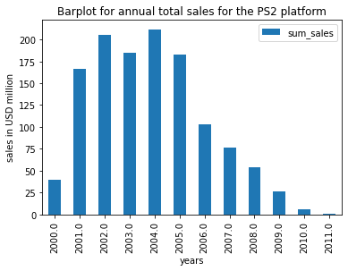

```python
PS2_games_each_year.plot(kind='bar');
plt.title("Barplot for annual total sales for the PS2 platform");
plt.xlabel('years');
plt.ylabel('sales in USD million');
```

The above barplot visualizes the trend of annual total sales for the PS2 platform very well. It shows that in 2000, the PS2 platform had about 39 USD million total sales. That number quickly jumped to 166 USD million in 2001. Then the total sales stayed high for another 4 years before it began to decrease almost linearly beginning 2006. In 2011, the annual total sales for the PS2 platform is very small. There was no data for its sales in 2012.

The PS2 platform is an example of platforms that used to be popular but now have zero sales. Are there any more platforms that used to be popular but now have zero sales? Let's find out.

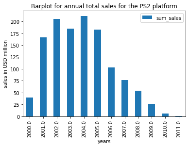

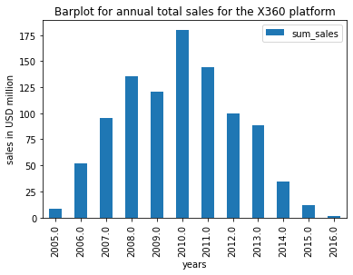

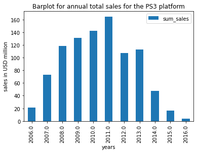

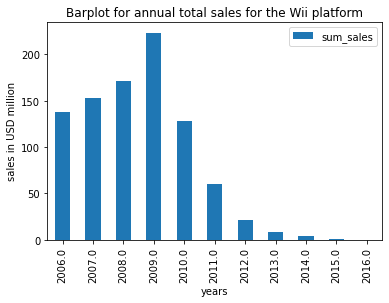

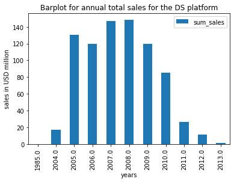

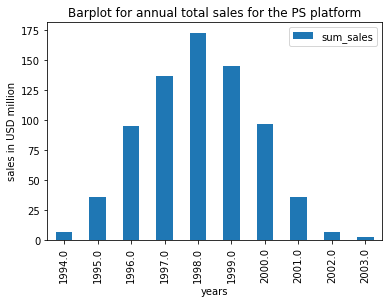

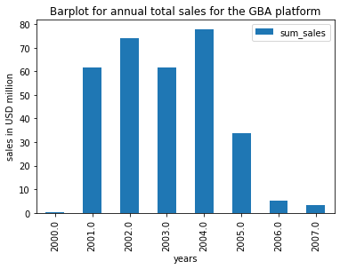

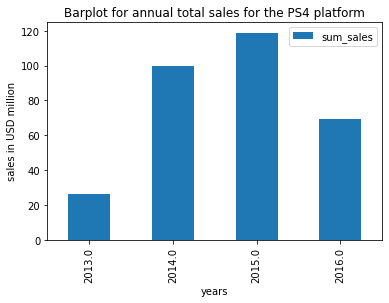

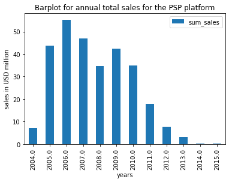

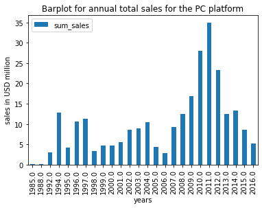

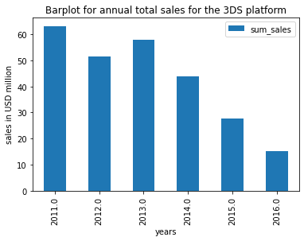

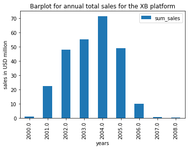

[19 more figures not shown]

```python
for i in range(len(sales_per_platform)):
    platform_games = games[games['platform'] == sales_per_platform.index[i]]
    platform_games_each_year = platform_games.pivot_table(index='year_of_release',
                     values='sum_sales',
                     aggfunc = 'sum')

    platform_games_each_year.plot(kind='bar');
    plt.title("Barplot for annual total sales for the " + sales_per_platform.index[i] + " platform");
    plt.xlabel('years');
    plt.ylabel('sales in USD million');
```

```python
games_2 = games[games['year_of_release']>=2012]
```

```python
games_2.reset_index(inplace=True, drop=True)
games_2
```

|  | name | platform | year_of_release | genre | na_sales | eu_sales | jp_sales | other_sales | critic_score | user_score | rating | sum_sales |
| --- | --- | --- | --- | --- | --- | --- | --- | --- | --- | --- | --- | --- |
| 0 | Grand Theft Auto V | PS3 | 2013.0 | Action | 7.02 | 9.09 | 0.98 | 3.96 | 97.0 | 82.0 | M | 21.05 |
| 1 | Grand Theft Auto V | X360 | 2013.0 | Action | 9.66 | 5.14 | 0.06 | 1.41 | 97.0 | 81.0 | M | 16.27 |
| 2 | Call of Duty: Black Ops 3 | PS4 | 2015.0 | Shooter | 6.03 | 5.86 | 0.36 | 2.38 | 76.0 | 76.0 | NaN | 14.63 |
| 3 | Pokemon X/Pokemon Y | 3DS | 2013.0 | Role-Playing | 5.28 | 4.19 | 4.35 | 0.78 | 74.0 | 74.0 | NaN | 14.60 |
| 4 | Call of Duty: Black Ops II | PS3 | 2012.0 | Shooter | 4.99 | 5.73 | 0.65 | 2.42 | 83.0 | 53.0 | M | 13.79 |
| ... | ... | ... | ... | ... | ... | ... | ... | ... | ... | ... | ... | ... |
| 2890 | Strawberry Nauts | PSV | 2016.0 | Adventure | 0.00 | 0.00 | 0.01 | 0.00 | 72.0 | 72.0 | NaN | 0.01 |
| 2891 | Aiyoku no Eustia | PSV | 2014.0 | Misc | 0.00 | 0.00 | 0.01 | 0.00 | 81.0 | 81.0 | NaN | 0.01 |
| 2892 | Samurai Warriors: Sanada Maru | PS3 | 2016.0 | Action | 0.00 | 0.00 | 0.01 | 0.00 | 71.0 | 71.0 | NaN | 0.01 |
| 2893 | Haitaka no Psychedelica | PSV | 2016.0 | Adventure | 0.00 | 0.00 | 0.01 | 0.00 | 72.0 | 72.0 | NaN | 0.01 |
| 2894 | Winning Post 8 2016 | PSV | 2016.0 | Simulation | 0.00 | 0.00 | 0.01 | 0.00 | NaN | NaN | NaN | 0.01 |

2895 rows × 12 columns

```python
sales_per_platform_2 = games_2.pivot_table(index='platform',
                     values='sum_sales',
                     aggfunc = 'sum')
sales_per_platform_2 = sales_per_platform_2.sort_values(['sum_sales'], ascending=False)
sales_per_platform_2
```

| platform | sum_sales |
| --- | --- |
| PS4 | 314.14 |
| PS3 | 288.79 |
| X360 | 236.54 |
| 3DS | 195.80 |
| XOne | 159.32 |
| WiiU | 82.19 |
| PC | 62.65 |
| PSV | 49.44 |
| Wii | 35.37 |
| DS | 12.55 |
| PSP | 11.19 |

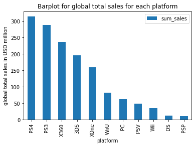

```python
sales_per_platform_2.plot(kind='bar');
plt.title("Barplot for global total sales for each platform");
plt.xlabel('platform');
plt.ylabel('global total sales in USD million');
```

The data from recent five years (from year 2012 to year 2016) shows that the first five leading platforms in total sales are PS4, PS3, X360, 3DS, and XOne. I think the differences in sales are significant.

```python
avg_sales_per_platform_2 = games_2.pivot_table(index='platform',
                     values='sum_sales',
                     aggfunc = 'mean')
avg_sales_per_platform_2 = avg_sales_per_platform_2.sort_values(['sum_sales'], ascending=False)
avg_sales_per_platform_2
```

| platform | sum_sales |
| --- | --- |
| X360 | 0.810068 |
| PS4 | 0.801378 |
| Wii | 0.655000 |
| XOne | 0.645020 |
| PS3 | 0.585781 |
| WiiU | 0.559116 |
| 3DS | 0.484653 |
| DS | 0.404839 |
| PC | 0.250600 |
| PSV | 0.120000 |
| PSP | 0.064682 |

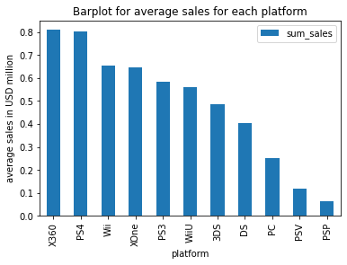

```python
avg_sales_per_platform_2.plot(kind='bar');
plt.title("Barplot for average sales for each platform");
plt.xlabel('platform');
plt.ylabel('average sales in USD million');
```

The barplot for average sales for each platform from recent five years (from year 2012 to year 2016) shows that the first two leading platforms in average sales were PS4 and X360. I think the differences in their average sales were not significant. The other platforms appeared to have significant smaller average sales.

[figure not shown]

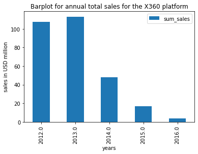

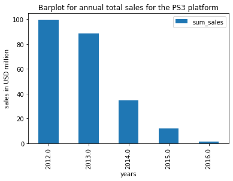

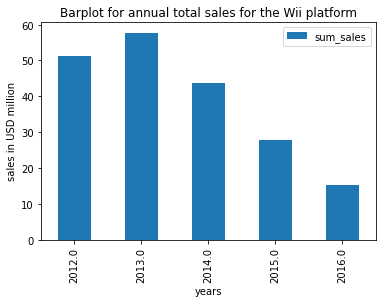

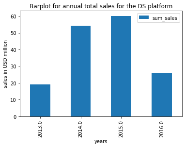

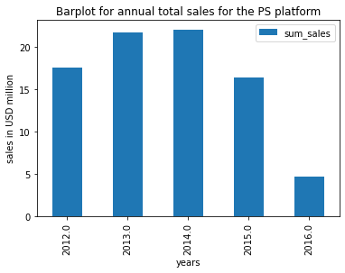

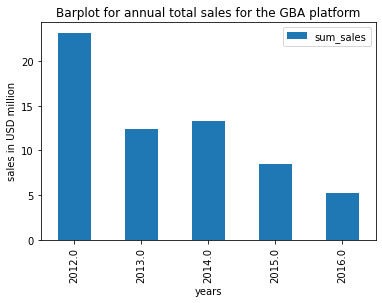

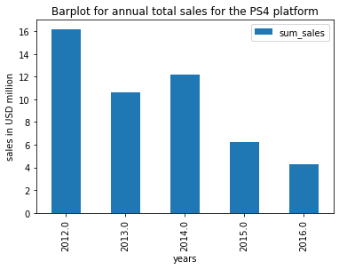

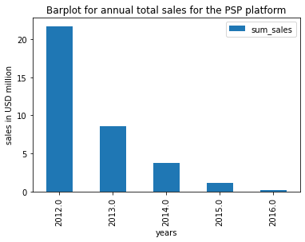

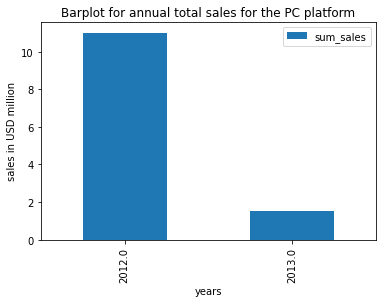

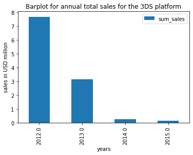

```python
for i in range(len(sales_per_platform_2)):
    platform_games = games_2[games_2['platform'] == sales_per_platform_2.index[i]]
    platform_games_each_year = platform_games.pivot_table(index='year_of_release',
                     values='sum_sales',
                     aggfunc = 'sum')

    platform_games_each_year.plot(kind='bar');
    plt.title("Barplot for annual total sales for the " + sales_per_platform.index[i] + " platform");
    plt.xlabel('years');
    plt.ylabel('sales in USD million');
```

### Sales and user and professional reviews for platform PS4

```python
ps4_data = games_2[games_2['platform'] == "PS4"]
ps4_data.reset_index(inplace=True, drop=True)
ps4_data
```

|  | name | platform | year_of_release | genre | na_sales | eu_sales | jp_sales | other_sales | critic_score | user_score | rating | sum_sales |
| --- | --- | --- | --- | --- | --- | --- | --- | --- | --- | --- | --- | --- |
| 0 | Call of Duty: Black Ops 3 | PS4 | 2015.0 | Shooter | 6.03 | 5.86 | 0.36 | 2.38 | 76.0 | 76.0 | NaN | 14.63 |
| 1 | Grand Theft Auto V | PS4 | 2014.0 | Action | 3.96 | 6.31 | 0.38 | 1.97 | 97.0 | 83.0 | M | 12.62 |
| 2 | FIFA 16 | PS4 | 2015.0 | Sports | 1.12 | 6.12 | 0.06 | 1.28 | 82.0 | 43.0 | E | 8.58 |
| 3 | Star Wars Battlefront (2015) | PS4 | 2015.0 | Shooter | 2.99 | 3.49 | 0.22 | 1.28 | 76.0 | 76.0 | NaN | 7.98 |
| 4 | Call of Duty: Advanced Warfare | PS4 | 2014.0 | Shooter | 2.81 | 3.48 | 0.14 | 1.23 | 83.0 | 57.0 | M | 7.66 |
| ... | ... | ... | ... | ... | ... | ... | ... | ... | ... | ... | ... | ... |
| 387 | Root Letter | PS4 | 2016.0 | Adventure | 0.00 | 0.00 | 0.01 | 0.00 | 69.0 | 75.0 | NaN | 0.01 |
| 388 | Shin Hayarigami 2 | PS4 | 2016.0 | Adventure | 0.00 | 0.00 | 0.01 | 0.00 | 72.0 | 72.0 | NaN | 0.01 |
| 389 | Dungeons 2 | PS4 | 2016.0 | Role-Playing | 0.01 | 0.00 | 0.00 | 0.00 | 61.0 | 79.0 | T | 0.01 |
| 390 | Carmageddon: Max Damage | PS4 | 2016.0 | Action | 0.01 | 0.00 | 0.00 | 0.00 | 51.0 | 55.0 | M | 0.01 |
| 391 | Farming 2017 - The Simulation | PS4 | 2016.0 | Simulation | 0.00 | 0.01 | 0.00 | 0.00 | 72.5 | 72.5 | NaN | 0.01 |

392 rows × 12 columns

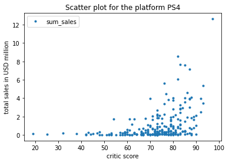

```python
ps4_data.dropna().plot(y='sum_sales', x='critic_score', style='.');
plt.title("Scatter plot for the platform PS4");
plt.xlabel('critic score');
plt.ylabel('total sales in USD million');
```

```python
print(ps4_data['sum_sales'].corr(ps4_data['critic_score']))
```

```
0.3347689328109688
```

The scatter plot shows a weak positive correlation between critic scores and total sales. The correlation coefficient is 0.33.

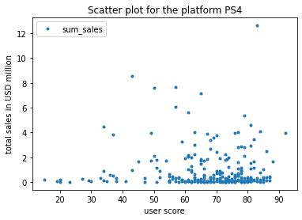

```python
ps4_data.dropna().plot(y='sum_sales', x='user_score', style='.');
plt.title("Scatter plot for the platform PS4");
plt.xlabel('user score');
plt.ylabel('total sales in USD million');
```

```python
print(ps4_data['sum_sales'].corr(ps4_data['user_score']))
```

```
-0.043493700088664926
```

The scatter plot shows no correlation between user scores and total sales. The correlation coefficient is almost zero. That is interesting. That may indicate user reviews were too subjective and not reliable.

### Total sales and genre

```python
total_sales_per_genre = games_2.pivot_table(index='genre',
                      values='sum_sales',
                      aggfunc = 'sum')
total_sales_per_genre = total_sales_per_genre.sort_values(['sum_sales'], ascending=False)
total_sales_per_genre
```

| genre | sum_sales |
| --- | --- |
| Action | 441.52 |
| Shooter | 304.80 |
| Role-Playing | 193.09 |
| Sports | 181.09 |
| Misc | 85.04 |
| Platform | 61.00 |
| Racing | 53.59 |
| Fighting | 44.49 |
| Simulation | 35.61 |
| Adventure | 29.52 |
| Strategy | 13.34 |
| Puzzle | 4.89 |

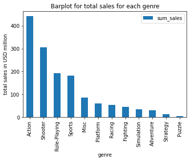

```python
total_sales_per_genre.plot(kind='bar');
plt.title("Barplot for total sales for each genre");
plt.xlabel('genre');
plt.ylabel('total sales in USD million');
```

It seems that the most profitable genre was Action. Second to that was Shooter. It looks reasonable to say that genres with high sales were Action, Shooter, Role-Playing and Sports. All other genres had relatively low sales.

## Create a user profile for each region

### The top five platforms in each region (NA, EU, JP)

```python
games_2
```

|  | name | platform | year_of_release | genre | na_sales | eu_sales | jp_sales | other_sales | critic_score | user_score | rating | sum_sales |
| --- | --- | --- | --- | --- | --- | --- | --- | --- | --- | --- | --- | --- |
| 0 | Grand Theft Auto V | PS3 | 2013.0 | Action | 7.02 | 9.09 | 0.98 | 3.96 | 97.0 | 82.0 | M | 21.05 |
| 1 | Grand Theft Auto V | X360 | 2013.0 | Action | 9.66 | 5.14 | 0.06 | 1.41 | 97.0 | 81.0 | M | 16.27 |
| 2 | Call of Duty: Black Ops 3 | PS4 | 2015.0 | Shooter | 6.03 | 5.86 | 0.36 | 2.38 | 76.0 | 76.0 | NaN | 14.63 |
| 3 | Pokemon X/Pokemon Y | 3DS | 2013.0 | Role-Playing | 5.28 | 4.19 | 4.35 | 0.78 | 74.0 | 74.0 | NaN | 14.60 |
| 4 | Call of Duty: Black Ops II | PS3 | 2012.0 | Shooter | 4.99 | 5.73 | 0.65 | 2.42 | 83.0 | 53.0 | M | 13.79 |
| ... | ... | ... | ... | ... | ... | ... | ... | ... | ... | ... | ... | ... |
| 2890 | Strawberry Nauts | PSV | 2016.0 | Adventure | 0.00 | 0.00 | 0.01 | 0.00 | 72.0 | 72.0 | NaN | 0.01 |
| 2891 | Aiyoku no Eustia | PSV | 2014.0 | Misc | 0.00 | 0.00 | 0.01 | 0.00 | 81.0 | 81.0 | NaN | 0.01 |
| 2892 | Samurai Warriors: Sanada Maru | PS3 | 2016.0 | Action | 0.00 | 0.00 | 0.01 | 0.00 | 71.0 | 71.0 | NaN | 0.01 |
| 2893 | Haitaka no Psychedelica | PSV | 2016.0 | Adventure | 0.00 | 0.00 | 0.01 | 0.00 | 72.0 | 72.0 | NaN | 0.01 |
| 2894 | Winning Post 8 2016 | PSV | 2016.0 | Simulation | 0.00 | 0.00 | 0.01 | 0.00 | NaN | NaN | NaN | 0.01 |

2895 rows × 12 columns

```python
total_sales_per_platform_na = games_2.pivot_table(index='platform',
                      values='na_sales',
                      aggfunc = 'sum')
total_sales_per_platform_na = total_sales_per_platform_na.sort_values(['na_sales'], ascending=False)
total_sales_per_platform_na
```

| platform | na_sales |
| --- | --- |
| X360 | 140.05 |
| PS4 | 108.74 |
| PS3 | 103.38 |
| XOne | 93.12 |
| 3DS | 56.15 |
| WiiU | 38.10 |
| PC | 19.12 |
| Wii | 17.45 |
| PSV | 11.09 |
| DS | 4.59 |
| PSP | 0.13 |

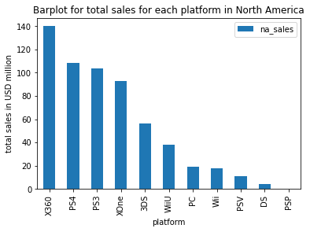

```python
total_sales_per_platform_na.plot(kind='bar');
plt.title("Barplot for total sales for each platform in North America");
plt.xlabel('platform');
plt.ylabel('total sales in USD million');
```

```python
total_sales_per_platform_eu = games_2.pivot_table(index='platform',
                      values='eu_sales',
                      aggfunc = 'sum')
total_sales_per_platform_eu = total_sales_per_platform_eu.sort_values(['eu_sales'], ascending=False)
total_sales_per_platform_eu
```

| platform | eu_sales |
| --- | --- |
| PS4 | 141.09 |
| PS3 | 106.86 |
| X360 | 74.52 |
| XOne | 51.59 |
| 3DS | 42.85 |
| PC | 37.76 |
| WiiU | 25.13 |
| Wii | 11.92 |
| PSV | 11.41 |
| DS | 3.53 |
| PSP | 0.42 |

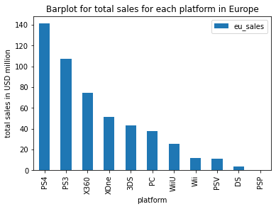

```python
total_sales_per_platform_eu.plot(kind='bar');
plt.title("Barplot for total sales for each platform in Europe");
plt.xlabel('platform');
plt.ylabel('total sales in USD million');
```

```python
total_sales_per_platform_jp = games_2.pivot_table(index='platform',
                      values='jp_sales',
                      aggfunc = 'sum')
total_sales_per_platform_jp = total_sales_per_platform_jp.sort_values(['jp_sales'], ascending=False)
total_sales_per_platform_jp
```

| platform | jp_sales |
| --- | --- |
| 3DS | 87.84 |
| PS3 | 35.29 |
| PSV | 21.11 |
| PS4 | 15.96 |
| WiiU | 13.01 |
| PSP | 10.47 |
| DS | 3.72 |
| Wii | 3.39 |
| X360 | 1.57 |
| XOne | 0.34 |
| PC | 0.00 |

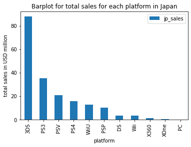

```python
total_sales_per_platform_jp.plot(kind='bar');
plt.title("Barplot for total sales for each platform in Japan");
plt.xlabel('platform');
plt.ylabel('total sales in USD million');
```

In terms of total sales for each platform:

- The top five platforms in North America were X360, PS4, PS3, XOne and 3DS, with total sales ranged from 56 USD million to 140 USD million.
- The top five platforms in Europe were PS4, PS3, X360, XOne and 3DS, with total sales ranged from 43 USD million to 141 USD million.
- The top five platforms in Japanwere 3DS, PS3, PSV, PS4, and WiiU, with total sales ranged from 13 USD million to 88 USD million..

In conclusion, platforms had the largest market shares in North America and the smallest market shares in Japan. Market shares in Europe ranked in the second place. The top five most popular platforms were similar in both North America and Europe. However, the Japan market had a quite different set of top five most popular platforms.